# Fuzzy Alpha-cut Linear Regression: MODIFIED TANAKA DATA

2018/ 11/ 15

We give an example to illustrate the mechanism of our fuzzy linear regression with $\alpha$-level loss function. The data presented below were taken from Hao and Chiang.

# TANAKA DATA, The House Price Example

The example dataset is given below.

```r
# Y is a fuzzy dataset.
y <- c(606, 710, 808, 826, 865, 852, 917, 1031,
       1092, 1203, 1394, 1420, 1601, 1632, 1699) # center of Dependent variable Y.
s <- c(100, 50, 100, 150, 250, 200, 200, 250, 600,
       100, 350, 250, 300, 500, 650) # spread of Dependent variable Y
f_Y <- cbind(y-s, y, y+s)

# Covariates x1, x2, x3 are crisp.
x1 <- c(38.09, 62.10, 63.76, 74.52, 75.38, 52.99, 62.93,
        72.04, 76.12, 90.26, 85.70, 95.27, 105.98, 79.25, 120.50)
x2 <- c(36.43, 26.50, 44.71, 38.09, 41.40, 26.49, 26.49, 33.12,
        43.06, 42.64, 31.33, 27.64, 27.64, 66.81, 32.25)
x3 <- c(5, 6, 7, 8, 7, 4, 5, 6, 7, 7, 6, 6, 6, 6, 6)
X <- cbind(x1, x2, x3)
sX <- scale(X, center = TRUE, scale = TRUE)
```

One of the assumptions of linear regression is that there is no multicollinearity between the explanatory variables. Multicollinearity can be detected in the following ways.

1. The pairwise correlation between the explanatory variables shows that the variables are not highly correlated to each other.

```r
cor(X)
```

```
##             x1          x2        x3
## x1  1.00000000 -0.02425946 0.3248383
## x2 -0.02425946  1.00000000 0.4004309
## x3  0.32483829  0.40043093 1.0000000
```

2. As the collinearity of $X_j$ with the other regressors increases, VIF also increases. As a rule of thumb, if the VIF of a variable > 5, that variable is said to be highly collinear. The results show multicollinearity is not an issue for the TANAKA dataset ($X_1, X_2, X_3$ VIF values < 2).

```r
vif(as.data.frame(X))
```

```
##   Variables      VIF
## 1        x1 1.154585
## 2        x2 1.229973
## 3        x3 1.374261
```

## STEP 1.

Create an $\alpha$ - level of the dependent variable Y. The set of $\alpha$ - levels is given by $A = \{1, 0.75, 0.5, 0.25, 0\}$.

```r
A <- c(1, 0.75, 0.5, 0.25, 0)
len.A <- length(A)

n <- length(y)
p <- ncol(X)

l_Y <- matrix(NA, nrow = n, ncol = len.A)
r_Y <- matrix(NA, nrow = n, ncol = len.A)

for (a in 1:len.A) {
  x_L <- s*A[a] + y - s
  x_R <- -s*A[a] + y + s

  l_Y[, a] <- x_L
  r_Y[, a] <- x_R
}

colnames(l_Y) <- c("l_Y(1)", "l_Y(0.75)", "l_Y(0.5)", "l_Y(0.25)", "l_Y(0)")
colnames(r_Y) <- c("r_Y(1)", "r_Y(0.75)", "r_Y(0.5)", "r_Y(0.25)", "r_Y(0)")
```

```r
l_Y
```

```
##       l_Y(1) l_Y(0.75) l_Y(0.5) l_Y(0.25) l_Y(0)
##  [1,]    606     581.0      556     531.0    506
##  [2,]    710     697.5      685     672.5    660
##  [3,]    808     783.0      758     733.0    708
##  [4,]    826     788.5      751     713.5    676
##  [5,]    865     802.5      740     677.5    615
##  [6,]    852     802.0      752     702.0    652
##  [7,]    917     867.0      817     767.0    717
##  [8,]   1031     968.5      906     843.5    781
##  [9,]   1092     942.0      792     642.0    492
## [10,]   1203    1178.0     1153    1128.0   1103
## [11,]   1394    1306.5     1219    1131.5   1044
## [12,]   1420    1357.5     1295    1232.5   1170
## [13,]   1601    1526.0     1451    1376.0   1301
## [14,]   1632    1507.0     1382    1257.0   1132
## [15,]   1699    1536.5     1374    1211.5   1049
```

```r
r_Y
```

```
##       r_Y(1) r_Y(0.75) r_Y(0.5) r_Y(0.25) r_Y(0)
##  [1,]    606     631.0      656     681.0    706
##  [2,]    710     722.5      735     747.5    760
##  [3,]    808     833.0      858     883.0    908
##  [4,]    826     863.5      901     938.5    976
##  [5,]    865     927.5      990    1052.5   1115
##  [6,]    852     902.0      952    1002.0   1052
##  [7,]    917     967.0     1017    1067.0   1117
##  [8,]   1031    1093.5     1156    1218.5   1281
##  [9,]   1092    1242.0     1392    1542.0   1692
## [10,]   1203    1228.0     1253    1278.0   1303
## [11,]   1394    1481.5     1569    1656.5   1744
## [12,]   1420    1482.5     1545    1607.5   1670
## [13,]   1601    1676.0     1751    1826.0   1901
## [14,]   1632    1757.0     1882    2007.0   2132
## [15,]   1699    1861.5     2024    2186.5   2349
```

## STEP 2. - STEP 5.

```r
l_Ak <- matrix(NA, nrow = p + 1, ncol = len.A)
r_Ak <- matrix(NA, nrow = p + 1, ncol = len.A)

l_Ak_var <- matrix(NA, nrow = p, ncol = len.A)
r_Ak_var <- matrix(NA, nrow = p, ncol = len.A)


for (a in 1:len.A) {
  # estimated fuzzy regression coefficients using glmnet.
  l_fit <- glmnet(X, l_Y[, a], alpha = 0, lambda = 0)
  r_fit <- glmnet(X, r_Y[, a], alpha = 0, lambda = 0)

  l_Ak[, a] <- as.matrix(coef(l_fit))
  r_Ak[, a] <- as.matrix(coef(r_fit))

  # std. errors for the estimated ridge fuzzy regression coefficients
  l_yhat   <- predict(l_fit, newx = X, s='lambda.min')
  r_yhat   <- predict(r_fit, newx = X, s='lambda.min')

  l_Ak_var[, a]   <- ridge_se(sX , y, l_yhat, l_fit)
  r_Ak_var[, a]   <- ridge_se(sX , y, r_yhat, r_fit)

  #l_summary <- summary(lm (l_Y[, a] ~ X))
  #r_summary <- summary(lm (r_Y[, a] ~ X))

  #l_Ak[, a] <- l_summary$coefficients[, 1] # Linear regression on X
  #r_Ak[, a] <- r_summary$coefficients[, 1]

  #l_Ak_var[, a] <- l_summary$coefficients[, 2]
  #r_Ak_var[, a] <- r_summary$coefficients[, 2]

  #betas_L[2:(p+1), a] <- lm (cY_L[, a] ~ sX)$coef[-1] # Linear regression on standardized X
  #betas_L[2:(p+1), a] <- betas_L[2:(p+1), a] / scaleX
  #betas_L[1,a] <- mean(Y_L[, a]) - betas_L[2:(p+1), a] %*% colMeans(X)  # Intercept

  #betas_R[2:(p+1), a] <- lm (cY_R[, a] ~ sX)$coef[-1]
  #betas_R[2:(p+1), a] <- betas_R[2:(p+1), a] / scaleX
  #betas_R[1,a] <- mean(Y_R[, a]) - betas_R[2:(p+1), a] %*% colMeans(X)  # Intercept
}

colnames(l_Ak) <- c("alpha = 1", "alpha = 0.75", "alpha = 0.5", "alpha = 0.25", "alpha = 0")
rownames(l_Ak) <- c("Intercept", "l_A1", "l_A2", "l_A3")

colnames(r_Ak) <- c("alpha = 1", "alpha = 0.75", "alpha = 0.5", "alpha = 0.25", "alpha = 0")
rownames(r_Ak) <- c("Intercept", "r_A1", "r_A2", "r_A3")

colnames(l_Ak_var) <- c("alpha = 1", "alpha = 0.75", "alpha = 0.5", "alpha = 0.25", "alpha = 0")
rownames(l_Ak_var) <- c("l_A1", "l_A2", "l_A3")

colnames(r_Ak_var) <- c("alpha = 1", "alpha = 0.75", "alpha = 0.5", "alpha = 0.25", "alpha = 0")
rownames(r_Ak_var) <- c("r_A1", "r_A2", "r_A3")
```

```r
l_Ak
```

```
##            alpha = 1 alpha = 0.75 alpha = 0.5 alpha = 0.25  alpha = 0
## Intercept  284.07443    303.10738  322.140333   341.173282 360.206232
## l_A1        17.66867     16.09880   14.528934    12.959066  11.389199
## l_A2        13.07923     11.13051    9.181787     7.233066   5.284346
## l_A3      -164.49383   -147.36010 -130.226374  -113.092645 -95.958916
```

```r
r_Ak
```

```
##            alpha = 1 alpha = 0.75 alpha = 0.5 alpha = 0.25  alpha = 0
## Intercept  284.07443    265.04149   246.00854    226.97559  207.94264
## r_A1        17.66867     19.23854    20.80840     22.37827   23.94814
## r_A2        13.07923     15.02795    16.97667     18.92539   20.87411
## r_A3      -164.49383   -181.62756  -198.76129   -215.89502 -233.02875
```

A Summary of the obtained above results in tabular is given below.

Summary of l_Ak

|  | l_A1 Estimate | l_A1 Std.Error | l_A2 Estimate | l_A2 Std.Error | l_A3 Estimate | l_A3 Std.Error |
| --- | --- | --- | --- | --- | --- | --- |
| alpha = 1 | 17.66867 | 26.75375 | 13.079227 | 27.61337 | -164.49383 | 29.18813 |
| alpha = 0.75 | 16.09880 | 35.95029 | 11.130507 | 37.10541 | -147.36010 | 39.22149 |
| alpha = 0.5 | 14.52893 | 54.97527 | 9.181787 | 56.74169 | -130.22637 | 59.97760 |
| alpha = 0.25 | 12.95907 | 76.84618 | 7.233066 | 79.31533 | -113.09265 | 83.83859 |
| alpha = 0 | 11.38920 | 99.70751 | 5.284346 | 102.91122 | -95.95892 | 108.78013 |

Summary of r_Ak

|  | r_A1 Estimate | r_A1 Std.Error | r_A2 Estimate | r_A2 Std.Error | r_A3 Estimate | r_A3 Std.Error |
| --- | --- | --- | --- | --- | --- | --- |
| alpha = 1 | 17.66867 | 26.75375 | 13.07923 | 27.61337 | -164.4938 | 29.18813 |
| alpha = 0.75 | 19.23854 | 35.94858 | 15.02795 | 37.10364 | -181.6276 | 39.21962 |
| alpha = 0.5 | 20.80840 | 54.97304 | 16.97667 | 56.73938 | -198.7613 | 59.97516 |
| alpha = 0.25 | 22.37827 | 76.84378 | 18.92539 | 79.31286 | -215.8950 | 83.83598 |
| alpha = 0 | 23.94814 | 99.70504 | 20.87411 | 102.90868 | -233.0287 | 108.77744 |

Modify the intermediate estimators $\bar{l_{A_{k}}}(\alpha)$, and $\bar{r_{A_{k}}}(\alpha)$ so that the estimated coefficients form a pre-defined shape of the membership function.

For each $A_k$, $k = 1, \cdots, p$, compare the $\alpha$ - levels with that of the previous level, i.e., use the *min* and *max* operators to obtain $\hat{l_{A_{k}}}(\alpha)$, and $\hat{r_{A_{k}}}(\alpha)$ for each $k = 1, \cdots, p$. Note that we do not modify the intercept.

```r
#l_A0 <- c(l_Ak[1,], r_Ak[1,]) # Keep the intercepts for late use.
#temp_l_Ak <- l_Ak[-1, ]
#temp_r_Ak <- r_Ak[-1, ]

temp_l_Ak <- l_Ak
temp_r_Ak <- r_Ak

for (i in 1:(p + 1)) {
  for (j in 2:len.A) {
    temp_l_Ak[i, j] <-  ifelse(temp_l_Ak[i, j] <= temp_l_Ak[i, j-1], temp_l_Ak[i, j], temp_l_Ak[i, j-1])
    temp_r_Ak[i, j] <-  ifelse(temp_r_Ak[i, j] >= temp_r_Ak[i, j-1], temp_r_Ak[i, j], temp_r_Ak[i, j-1])
  }
}

temp_lr_Ak <- data.frame(t(temp_l_Ak), t(temp_r_Ak))
```

```r
temp_lr_Ak
```

```
##              Intercept     l_A1      l_A2      l_A3 Intercept.1     r_A1
## alpha = 1     284.0744 17.66867 13.079227 -164.4938    284.0744 17.66867
## alpha = 0.75  284.0744 16.09880 11.130507 -164.4938    284.0744 19.23854
## alpha = 0.5   284.0744 14.52893  9.181787 -164.4938    284.0744 20.80840
## alpha = 0.25  284.0744 12.95907  7.233066 -164.4938    284.0744 22.37827
## alpha = 0     284.0744 11.38920  5.284346 -164.4938    284.0744 23.94814
##                  r_A2      r_A3
## alpha = 1    13.07923 -164.4938
## alpha = 0.75 15.02795 -164.4938
## alpha = 0.5  16.97667 -164.4938
## alpha = 0.25 18.92539 -164.4938
## alpha = 0    20.87411 -164.4938
```

## STEP 6.

Find the membership function $\mu_{A_{k}}(x)$ for the fuzzy regression coefficients $A_{k}$, $k = 1, \cdots, p$ by performing linear regression on the estimated $\alpha$ -level sets $\hat{A_{k}}(\alpha_j) = [\hat{l_{A_{k}}}(\alpha_j), \hat{r_{A_{k}}}(\alpha_j)]$, for all $\alpha \in A$. Give constraints so that the top of the pre-defined membership function satisfy the condition of $\alpha$ - level 1.

### 1.

Find each of the left and right slopes for the pre-defined membership function.

```r
(lr_Ak <- data.frame(y = A,
                    temp_lr_Ak))
```

```
##                 y Intercept     l_A1      l_A2      l_A3 Intercept.1
## alpha = 1    1.00  284.0744 17.66867 13.079227 -164.4938    284.0744
## alpha = 0.75 0.75  284.0744 16.09880 11.130507 -164.4938    284.0744
## alpha = 0.5  0.50  284.0744 14.52893  9.181787 -164.4938    284.0744
## alpha = 0.25 0.25  284.0744 12.95907  7.233066 -164.4938    284.0744
## alpha = 0    0.00  284.0744 11.38920  5.284346 -164.4938    284.0744
##                  r_A1     r_A2      r_A3
## alpha = 1    17.66867 13.07923 -164.4938
## alpha = 0.75 19.23854 15.02795 -164.4938
## alpha = 0.5  20.80840 16.97667 -164.4938
## alpha = 0.25 22.37827 18.92539 -164.4938
## alpha = 0    23.94814 20.87411 -164.4938
```

```r
slopes <- matrix(NA, nrow = (p + 1), ncol = 3)

for (i in 1:(p + 1)) {
  # left slope
  slopes[i, 1] <- lm(I(lr_Ak[, 1] - lr_Ak[1, 1]) ~ I(lr_Ak[, (i + 1)] - lr_Ak[1, (i + 1)]) + 0)$coef
  # center value
  slopes[i, 2] <- lr_Ak[1, (i + 1)]  #### changed!!
  # right slope
  slopes[i, 3] <- lm(I(lr_Ak[, 1] - lr_Ak[1, 1]) ~ I(lr_Ak[, (i + p + 2)] - lr_Ak[1, (i + p + 2)]) + 0)$coef
}

rownames(slopes) <- c("Intercept", "A1", "A2", "A3")
colnames(slopes) <- c("left.slope", "Ak(1)","right.slope")
```

```r
slopes
```

```
##           left.slope      Ak(1) right.slope
## Intercept         NA  284.07443          NA
## A1         0.1592491   17.66867  -0.1592491
## A2         0.1282893   13.07923  -0.1282893
## A3                NA -164.49383          NA
```

### 2.

Choose the left or the right slope based on MSE.

1. Choose the left/right slope then make symmetric

```r
# Choose the left slope then make symmetric
l_slopes <- cbind(slopes[,1], slopes[,2], -slopes[,1])
colnames(l_slopes) <- c("left.slope", "Ak(1)","right.slope")

# Choose the right slope then make symmetric
r_slopes <- cbind(-slopes[,3], slopes[,2], slopes[,3])
colnames(r_slopes) <- c("left.slope", "Ak(1)","right.slope")
```

2. Compute $\hat{l_{A_{k}}}(0)$, and $\hat{r_{A_{k}}}(0)$ for each methods using the obtained slope for the pre-defined membership function.

```r
# The left slope chosen.
l_f_Ak <- matrix(NA, nrow = (p + 1), ncol = 3)

for (i in 1:(p + 1)) {
  l_f_Ak[i, 1] <- l_slopes[i,2] - (1 / l_slopes[i,1])
  l_f_Ak[i, 2] <- l_slopes[i,2]
  l_f_Ak[i, 3] <- l_slopes[i,2] - (1 / l_slopes[i,3])

  l_f_Ak[is.na(l_f_Ak)] <- l_f_Ak[i,2] # Fill in NA values
}

rownames(l_f_Ak) <- c("Intercept", "A1", "A2", "A3")
colnames(l_f_Ak) <- c("l_Ak(0)", "Ak(1)", "r_Ak(0)")

# The right slope chosen.
r_f_Ak <- matrix(NA, nrow = (p + 1), ncol = 3)

for (i in 1:(p + 1)) {
  r_f_Ak[i, 1] <- r_slopes[i,2] - (1 / r_slopes[i,1])
  r_f_Ak[i, 2] <- r_slopes[i,2]
  r_f_Ak[i, 3] <- r_slopes[i,2] - (1 / r_slopes[i,3])

  r_f_Ak[is.na(r_f_Ak)] <- r_f_Ak[i,2] # Fill in NA values
}

rownames(r_f_Ak) <- c("Intercept", "A1", "A2", "A3")
colnames(r_f_Ak) <- c("l_Ak(0)", "Ak(1)", "r_Ak(0)")
```

```r
l_f_Ak
```

```
##               l_Ak(0)      Ak(1)    r_Ak(0)
## Intercept  284.074434  284.07443  284.07443
## A1          11.389199   17.66867   23.94814
## A2           5.284346   13.07923   20.87411
## A3        -164.493832 -164.49383 -164.49383
```

```r
r_f_Ak
```

```
##               l_Ak(0)      Ak(1)    r_Ak(0)
## Intercept  284.074434  284.07443  284.07443
## A1          11.389199   17.66867   23.94814
## A2           5.284346   13.07923   20.87411
## A3        -164.493832 -164.49383 -164.49383
```

To be sure, compare with the results from `lm`.

```r
coef(lm(y ~ X))
```

```
## (Intercept)         Xx1         Xx2         Xx3
##   284.05274    17.66905    13.08007  -164.50009
```

3. Compute the fuzzy predicted values for each of the methods. Note that since we defined the fuzzy regression coefficients as symmetric, the fuzzy predicted values are symmetric as well.

```r
# Calculate the intercept
#f_1 <- cbind(rep(1, n) * l_A0[len.A], rep(1, n) * l_A0[1], rep(1, n) * l_A0[2*len.A]) # 1 * beta0
# Calculate fuzzy predicted values for the left slope chosen.
f_1  <- cbind(rep(1, n) * l_f_Ak[1, 1], rep(1, n) * l_f_Ak[1, 2], rep(1, n) * l_f_Ak[1, 3])
f_XL <- X %*% l_f_Ak[2:(p+1), 1]
f_XC <- X %*% l_f_Ak[2:(p+1), 2]
f_XR <- X %*% l_f_Ak[2:(p+1), 3]

f_X <- cbind(f_XL, f_XC, f_XR)
(l_f_Yhat <- f_1 + f_X)
```

```
##            [,1]      [,2]     [,3]
##  [1,]  87.92858  611.0811 1134.234
##  [2,] 144.41586  740.9353 1337.455
##  [3,]  95.05604  843.9442 1592.832
##  [4,]  18.12762  782.9807 1547.834
##  [5,] 209.90735 1005.9619 1802.016
##  [6,] 369.59508  908.8306 1448.066
##  [7,] 318.30989  919.9633 1521.617
##  [8,] 292.60687 1003.1463 1713.686
##  [9,] 227.10737 1040.7482 1854.389
## [10,] 385.93122 1285.0899 2184.249
## [11,] 438.72435 1221.0885 2003.453
## [12,] 528.21975 1341.9154 2155.611
## [13,] 650.19807 1531.1468 2412.096
## [14,] 552.75261 1571.1766 2589.601
## [15,] 839.93007 1847.9911 2856.052
```

```r
# Calculate fuzzy predicted values for the right slope chosen.
f_1  <- cbind(rep(1, n) * r_f_Ak[1, 1], rep(1, n) * r_f_Ak[1, 2], rep(1, n) * r_f_Ak[1, 3])
f_XL <- X %*% r_f_Ak[2:(p+1), 1]
f_XC <- X %*% r_f_Ak[2:(p+1), 2]
f_XR <- X %*% r_f_Ak[2:(p+1), 3]

f_X <- cbind(f_XL, f_XC, f_XR)
(r_f_Yhat <- f_1 + f_X)
```

```
##            [,1]      [,2]     [,3]
##  [1,]  87.92858  611.0811 1134.234
##  [2,] 144.41586  740.9353 1337.455
##  [3,]  95.05604  843.9442 1592.832
##  [4,]  18.12762  782.9807 1547.834
##  [5,] 209.90735 1005.9619 1802.016
##  [6,] 369.59508  908.8306 1448.066
##  [7,] 318.30989  919.9633 1521.617
##  [8,] 292.60687 1003.1463 1713.686
##  [9,] 227.10737 1040.7482 1854.389
## [10,] 385.93122 1285.0899 2184.249
## [11,] 438.72435 1221.0885 2003.453
## [12,] 528.21975 1341.9154 2155.611
## [13,] 650.19807 1531.1468 2412.096
## [14,] 552.75261 1571.1766 2589.601
## [15,] 839.93007 1847.9911 2856.052
```

To be sure, compare the mid-values of the fuzzy predicted values with the predicted values from `lm`.

```r
predict(lm(y ~ X))
```

```
##         1         2         3         4         5         6         7
##  611.0734  740.9222  843.9408  782.9696 1005.9601  908.8265  919.9568
##         8         9        10        11        12        13        14
## 1003.1426 1040.7481 1285.0949 1221.0885 1341.9159 1531.1514 1571.2040
##        15
## 1848.0052
```

4. Compute RMSE and MAPE for between the observed fuzzy values $Y$ and the fitted fuzzy values $\hat{Y}$ for each of the two methods, respectively.

```r
### The left slope chosen
# RMSE
(RMSE <- sqrt(sum(rowSums((f_Y - l_f_Yhat)^2)) / n))
```

```
## [1] 743.2545
```

```r
# MAPE
f_diff <- f_Y - l_f_Yhat
for (i in 1:3) {
  f_diff[,i] <- abs(f_diff[,i] / f_Y[,i])
}

(MAPE <- sum(rowSums(f_diff))/n)
```

```
## [1] 1.095278
```

```r
### The right slope chosen
# RMSE
(RMSE <- sqrt(sum(rowSums((f_Y - r_f_Yhat)^2)) / n))
```

```
## [1] 743.2545
```

```r
# MAPE
f_diff <- f_Y - r_f_Yhat
for (i in 1:3) {
  f_diff[,i] <- abs(f_diff[,i] / f_Y[,i])
}

(MAPE <- sum(rowSums(f_diff))/n)
```

```
## [1] 1.095278
```

Since for the fuzzy linear regression the RMSE and MAPE for the right slope is the same, we choose the left slope, then perform symmetrization.

Finally, plot each of the fuzzy regression coefficients.

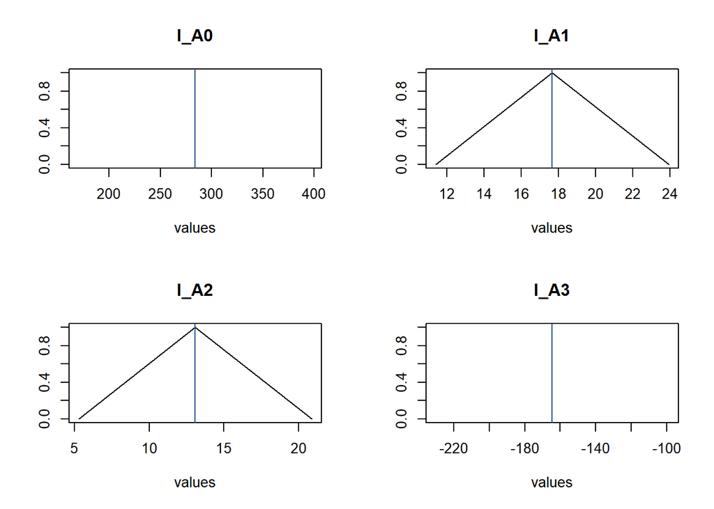

```r
par(mfrow = c(2,2))

for (i in 1:(p + 1)) {
  left.slope <- function(x) {l_slopes[i,1] * (x - l_slopes[i,2]) + 1}
  right.slope <- function(x) {l_slopes[i,3] * (x - l_slopes[i,2]) + 1}

  min_x <- r_f_Ak[i, 1]
  max_x <- r_f_Ak[i, 3]

  x_left <- c(min_x, l_f_Ak[i, 2])
  x_right <- c(l_f_Ak[i, 2], max_x)
  x <- c(x_left, x_right)

  #beta_triangle <- cbind(x, c(left(x_left), right(x_right)))
  #beta_triangle <- as.tibble(beta_triangle)
  #colnames(beta_triangle) <- c("x", "y")
  #
  #q <- ggplot(beta_triangle, aes(x, y)) +
  #  geom_line() +
  #  xlim(min_x, max_x) +
  #  ylim(0, 1) +
  #  geom_vline(xintercept =  coef[i,2], aes(colour = "red")) +
  #  labs(title = str_c("beta", i - 1),
  #     x = "Lambdas",
  #     y = "Coefficients") +
  #  theme(panel.background = element_rect(fill = "white", colour = "grey50"))
  #
  #print(q)

  plot(x, c(left.slope(x_left), right.slope(x_right)), type = "l",
       xlim = c(min_x, max_x), ylim = c(0, 1),
       main = str_c("l_A", i-1), ylab = " ", xlab = "values")
  abline(v = l_slopes[i,2], col = "dodgerblue4")
}
```

### Fuzzy Predicted Values

Using the fuzzy regression coefficients we have estimated above, we can compute the fuzzy predicted values as well. Note that since we defined the fuzzy regression coefficients as symmetric, the fuzzy predicted values are symmetric as well.

```r
f_1  <- cbind(rep(1, n) * r_f_Ak[1, 1], rep(1, n) * r_f_Ak[1, 2], rep(1, n) * l_f_Ak[1, 3])
f_XL <- X %*% l_f_Ak[2:(p+1), 1]
f_XC <- X %*% l_f_Ak[2:(p+1), 2]
f_XR <- X %*% l_f_Ak[2:(p+1), 3]

f_X <- cbind(f_XL, f_XC, f_XR)
(f_Yhat <- f_1 + f_X)
```

```
##            [,1]      [,2]     [,3]
##  [1,]  87.92858  611.0811 1134.234
##  [2,] 144.41586  740.9353 1337.455
##  [3,]  95.05604  843.9442 1592.832
##  [4,]  18.12762  782.9807 1547.834
##  [5,] 209.90735 1005.9619 1802.016
##  [6,] 369.59508  908.8306 1448.066
##  [7,] 318.30989  919.9633 1521.617
##  [8,] 292.60687 1003.1463 1713.686
##  [9,] 227.10737 1040.7482 1854.389
## [10,] 385.93122 1285.0899 2184.249
## [11,] 438.72435 1221.0885 2003.453
## [12,] 528.21975 1341.9154 2155.611
## [13,] 650.19807 1531.1468 2412.096
## [14,] 552.75261 1571.1766 2589.601
## [15,] 839.93007 1847.9911 2856.052
```

```r
f_Yhat[,3] - f_Yhat[,2]
```

```
##  [1]  523.1525  596.5194  748.8881  764.8531  796.0545  539.2355  601.6534
##  [8]  710.5395  813.6408  899.1587  782.3642  813.6956  880.9487 1018.4240
## [15] 1008.0610
```

```r
f_Yhat[,2] - f_Yhat[,1]
```

```
##  [1]  523.1525  596.5194  748.8881  764.8531  796.0545  539.2355  601.6534
##  [8]  710.5395  813.6408  899.1587  782.3642  813.6956  880.9487 1018.4240
## [15] 1008.0610
```

```r
f_Y
```

```
##               y
##  [1,]  506  606  706
##  [2,]  660  710  760
##  [3,]  708  808  908
##  [4,]  676  826  976
##  [5,]  615  865 1115
##  [6,]  652  852 1052
##  [7,]  717  917 1117
##  [8,]  781 1031 1281
##  [9,]  492 1092 1692
## [10,] 1103 1203 1303
## [11,] 1044 1394 1744
## [12,] 1170 1420 1670
## [13,] 1301 1601 1901
## [14,] 1132 1632 2132
## [15,] 1049 1699 2349
```

Compute RMSE and MAPE for between the observed fuzzy values $Y$ and the fitted fuzzy values $\hat{Y}$.

```r
### The left slope chosen
# RMSE
(RMSE <- sqrt(sum(rowSums((f_Y - f_Yhat)^2)) / n))
```

```
## [1] 743.2545
```

```r
# MAPE
f_diff <- f_Y - f_Yhat
for (i in 1:3) {
  f_diff[,i] <- abs(f_diff[,i] / f_Y[,i])
}

(MAPE <- sum(rowSums(f_diff))/n)
```

```
## [1] 1.095278
```

The plot of the observed values and the fitted values is shown below.

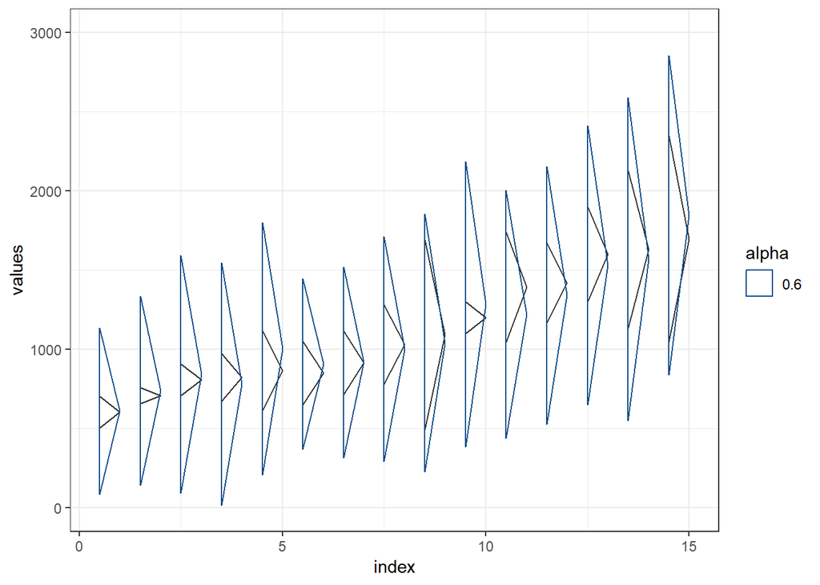